# EDA-bray

## 1. Exploring categorical variables

levels() returns factor levels

table() returns contingency table

```r
list.files()
```

```
[1] "cars04.csv"                "ch1.pdf"                   "comics.csv"
[4] "immigration.csv"           "life_exp_raw.csv"          "names.txt"
[7] "notes-dc-eda-bray.nb.html" "notes-dc-eda-bray.Rmd"     "us_income_raw.csv"
```

```r
comics <- read.csv("comics.csv")
# Check levels of align
levels(comics$align)
```

```
[1] "Bad"                "Good"               "Neutral"            "Reformed Criminals"
```

```r
# Check the levels of gender
levels(comics$gender)
```

```
[1] "Female" "Male"   "Other"
```

```r
# Create a 2-way contingency table
tab <- table(comics$align, comics$gender)
```

dropping levels

```r
library(dplyr)
# Remove align level
comics <- comics %>%
  filter(align != "Reformed Criminals") %>%
  droplevels()
```

side-by-side barcharts

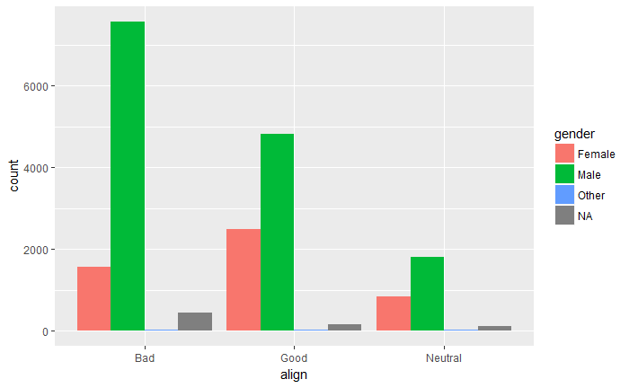

```r
# Load ggplot2
library(ggplot2)
# Create side-by-side barchart of gender by alignment
ggplot(comics, aes(x = align, fill = gender)) +
  geom_bar(position = "dodge")
```

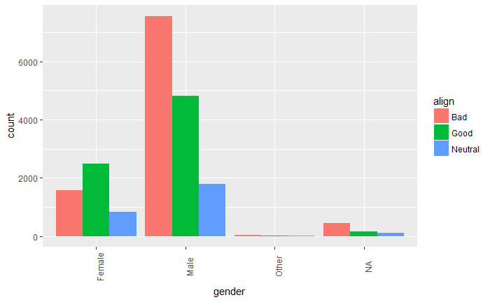

```r
# Create side-by-side barchart of alignment by gender
ggplot(comics, aes(x = gender, fill = align)) +
  geom_bar(position = "dodge") +
  theme(axis.text.x = element_text(angle = 90))
```

counts vs proportions

prop.table() proportions

sum(prop.table()) equals one

prop.table( , 1 or 2) conditions or rows or columns

```r
tab <- table(comics$align, comics$gender)
options(scipen = 999, digits = 3) # Print fewer digits
prop.table(tab)     # Joint proportions
```

```
            Female     Male    Other
  Bad     0.082210 0.395160 0.001672
  Good    0.130135 0.251333 0.000888
  Neutral 0.043692 0.094021 0.000888
```

```r
prop.table(tab, 2)  # Conditional on columns
```

```
          Female  Male Other
  Bad      0.321 0.534 0.485
  Good     0.508 0.339 0.258
  Neutral  0.171 0.127 0.258
```

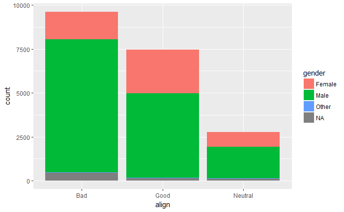

```r
# Plot of gender by align
ggplot(comics, aes(x = align, fill = gender)) +
  geom_bar()
```

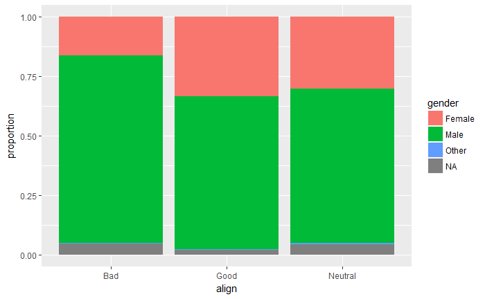

```r
# Plot proportion of gender, conditional on align
ggplot(comics, aes(x = align, fill = gender)) +
  geom_bar(position = "fill") +
  ylab("proportion")
```

Distribution of one variable

filter or facet to condition tilde (~) can be read as “broken down by”

generally bar charts > pie charts

```r
# Change the order of the levels in align
comics$align <- factor(comics$align,
                       levels = c("Bad", "Neutral", "Good"))

# Create plot of align
ggplot(comics, aes(x = align)) +
  geom_bar()
```

[output not shown]

[figure not shown]

```r
# Plot of alignment broken down by gender
ggplot(comics, aes(x = align)) +
  geom_bar() +
  facet_wrap(~ gender)
```

improve piechart

```r
# Put levels of flavor in decending order
lev <- c("apple", "key lime", "boston creme", "blueberry", "cherry", "pumpkin", "strawberry")
pies$flavor <- factor(pies$flavor, levels = lev)
```

```
Error in factor(pies$flavor, levels = lev) : object 'pies' not found
```

## 2. Exploring numerical data

dotplot zero information loss histogram aggregates with binning (some information loss) density plot for larger sets

```r
library(ggplot2)
cars <- read.csv("cars04.csv")
str(cars)
```

```
'data.frame':   428 obs. of  19 variables:
 $ name       : Factor w/ 425 levels "Acura 3.5 RL 4dr",..: 66 67 68 69 70 114 115 133 129 130 ...
 $ sports_car : logi  FALSE FALSE FALSE FALSE FALSE FALSE ...
 $ suv        : logi  FALSE FALSE FALSE FALSE FALSE FALSE ...
 $ wagon      : logi  FALSE FALSE FALSE FALSE FALSE FALSE ...
 $ minivan    : logi  FALSE FALSE FALSE FALSE FALSE FALSE ...
 $ pickup     : logi  FALSE FALSE FALSE FALSE FALSE FALSE ...
 $ all_wheel  : logi  FALSE FALSE FALSE FALSE FALSE FALSE ...
 $ rear_wheel : logi  FALSE FALSE FALSE FALSE FALSE FALSE ...
 $ msrp       : int  11690 12585 14610 14810 16385 13670 15040 13270 13730 15460 ...
 $ dealer_cost: int  10965 11802 13697 13884 15357 12849 14086 12482 12906 14496 ...
 $ eng_size   : num  1.6 1.6 2.2 2.2 2.2 2 2 2 2 2 ...
 $ ncyl       : int  4 4 4 4 4 4 4 4 4 4 ...
 $ horsepwr   : int  103 103 140 140 140 132 132 130 110 130 ...
 $ city_mpg   : int  28 28 26 26 26 29 29 26 27 26 ...
 $ hwy_mpg    : int  34 34 37 37 37 36 36 33 36 33 ...
 $ weight     : int  2370 2348 2617 2676 2617 2581 2626 2612 2606 2606 ...
 $ wheel_base : int  98 98 104 104 104 105 105 103 103 103 ...
 $ length     : int  167 153 183 183 183 174 174 168 168 168 ...
 $ width      : int  66 66 69 68 69 67 67 67 67 67 ...
```

```r
# Learn data structure
str(cars)
```

```
'data.frame':   428 obs. of  19 variables:
 $ name       : Factor w/ 425 levels "Acura 3.5 RL 4dr",..: 66 67 68 69 70 114 115 133 129 130 ...
 $ sports_car : logi  FALSE FALSE FALSE FALSE FALSE FALSE ...
 $ suv        : logi  FALSE FALSE FALSE FALSE FALSE FALSE ...
 $ wagon      : logi  FALSE FALSE FALSE FALSE FALSE FALSE ...
 $ minivan    : logi  FALSE FALSE FALSE FALSE FALSE FALSE ...
 $ pickup     : logi  FALSE FALSE FALSE FALSE FALSE FALSE ...
 $ all_wheel  : logi  FALSE FALSE FALSE FALSE FALSE FALSE ...
 $ rear_wheel : logi  FALSE FALSE FALSE FALSE FALSE FALSE ...
 $ msrp       : int  11690 12585 14610 14810 16385 13670 15040 13270 13730 15460 ...
 $ dealer_cost: int  10965 11802 13697 13884 15357 12849 14086 12482 12906 14496 ...
 $ eng_size   : num  1.6 1.6 2.2 2.2 2.2 2 2 2 2 2 ...
 $ ncyl       : int  4 4 4 4 4 4 4 4 4 4 ...
 $ horsepwr   : int  103 103 140 140 140 132 132 130 110 130 ...
 $ city_mpg   : int  28 28 26 26 26 29 29 26 27 26 ...
 $ hwy_mpg    : int  34 34 37 37 37 36 36 33 36 33 ...
 $ weight     : int  2370 2348 2617 2676 2617 2581 2626 2612 2606 2606 ...
 $ wheel_base : int  98 98 104 104 104 105 105 103 103 103 ...
 $ length     : int  167 153 183 183 183 174 174 168 168 168 ...
 $ width      : int  66 66 69 68 69 67 67 67 67 67 ...
```

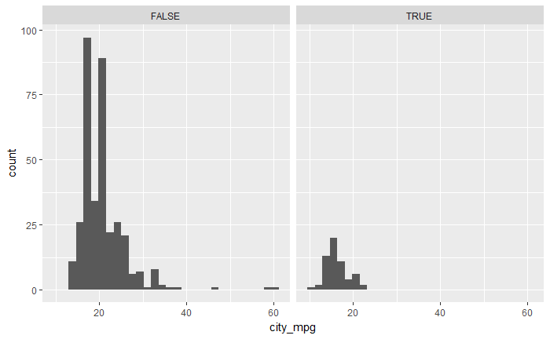

```r
# Create faceted histogram
ggplot(cars, aes(x = city_mpg)) +
  geom_histogram() +
  facet_wrap(~ suv)
```

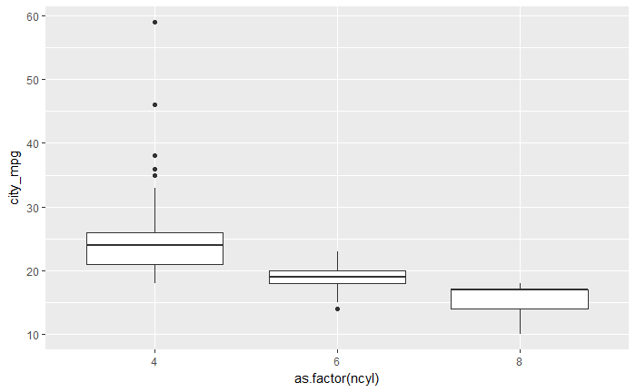

```r
# Filter cars with 4, 6, 8 cylinders
common_cyl <- filter(cars, ncyl %in% c(4,6,8))
# Create box plots of city mpg by ncyl
ggplot(common_cyl, aes(x = as.factor(ncyl), y = city_mpg)) +
  geom_boxplot()
```

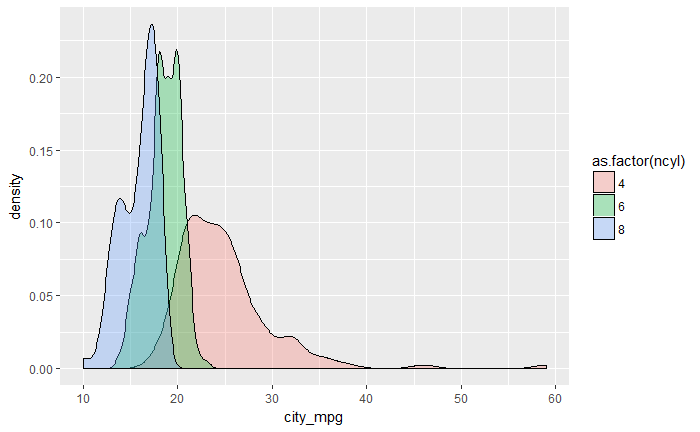

```r
# Create overlaid density plots for same data
ggplot(common_cyl, aes(x = city_mpg, fill = as.factor(ncyl))) +
  geom_density(alpha = .3)
```

Distribution of one variable

marginal and conditional histograms

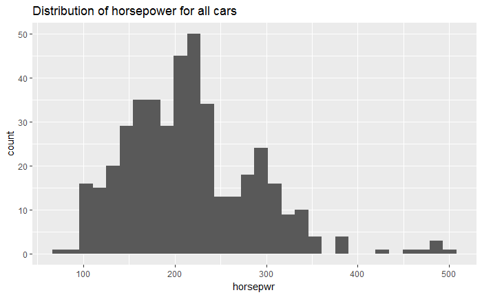

```r
# Create hist of horsepwr
cars %>%
  ggplot(aes(x = horsepwr)) +
  geom_histogram() +
  ggtitle("Distribution of horsepower for all cars")
```

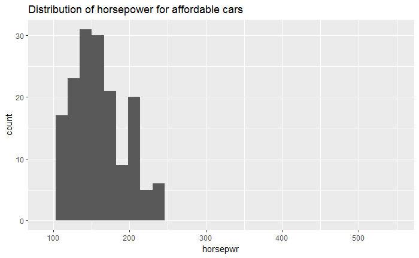

```r
# Create hist of horsepwr for affordable cars
cars %>%
  filter(msrp < 25000) %>%
  ggplot(aes(x = horsepwr)) +
  geom_histogram() +
  xlim(c(90, 550)) +
  ggtitle("Distribution of horsepower for affordable cars")
```

Box plots

box plot based on 1st, 2nd (median), and 3rd quartile

whiskers incorportes “almost all of the data” except identified outliers

weakness of box plot is cannot identify multiple modes

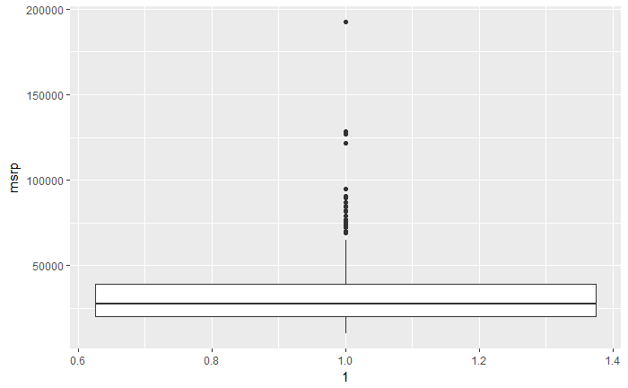

```r
# Construct box plot of msrp
cars %>%
  ggplot(aes(x = 1, y = msrp)) +
  geom_boxplot()
```

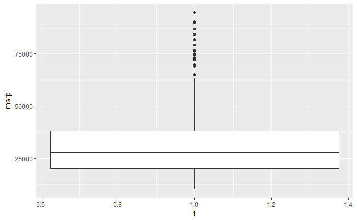

```r
# Exclude outliers from data
cars_no_out <- cars %>%
  filter(msrp < 100000)
# Construct box plot of msrp using the reduced dataset
cars_no_out %>%
  ggplot(aes(x = 1, y = msrp)) +
  geom_boxplot()
```

```r
NA
```

Plot selection

“Because the city_mpg variable has a much wider range with its outliers, it’s best to display its distribution as a box plot.”

```r
# Create plot of city_mpg
cars %>%
  ggplot(aes(x = 1, y = city_mpg)) +
  geom_boxplot()

# Create plot of width
cars %>%
  ggplot(aes(x = width)) +
  geom_density()
```

[output not shown]

Visualizing in higher dimensions

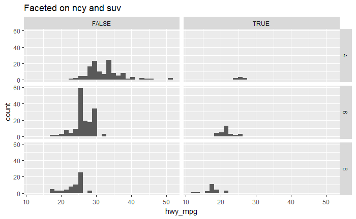

```r
# Facet hists using hwy mileage and ncyl
common_cyl %>%
  ggplot(aes(x = hwy_mpg)) +
  geom_histogram() +
  facet_grid(ncyl ~ suv) +
  ggtitle("Faceted on ncy and suv")
```

## 3. Numerical Summaries

```r
library(gapminder); library(dplyr)
data(gapminder)
str(gapminder)
```

```
Classes ‘tbl_df’, ‘tbl’ and 'data.frame':   1704 obs. of  6 variables:
 $ country  : Factor w/ 142 levels "Afghanistan",..: 1 1 1 1 1 1 1 1 1 1 ...
 $ continent: Factor w/ 5 levels "Africa","Americas",..: 3 3 3 3 3 3 3 3 3 3 ...
 $ year     : int  1952 1957 1962 1967 1972 1977 1982 1987 1992 1997 ...
 $ lifeExp  : num  28.8 30.3 32 34 36.1 ...
 $ pop      : int  8425333 9240934 10267083 11537966 13079460 14880372 12881816 13867957 16317921 22227415 ...
 $ gdpPercap: num  779 821 853 836 740 ...
```

```r
glimpse(gapminder)
```

```
Observations: 1,704
Variables: 6
$ country   <fctr> Afghanistan, Afghanistan, Afghanistan, Afghanistan, Afghanistan, Afghanistan,...
$ continent <fctr> Asia, Asia, Asia, Asia, Asia, Asia, Asia, Asia, Asia, Asia, Asia, Asia, Europ...
$ year      <int> 1952, 1957, 1962, 1967, 1972, 1977, 1982, 1987, 1992, 1997, 2002, 2007, 1952, ...
$ lifeExp   <dbl> 28.801, 30.332, 31.997, 34.020, 36.088, 38.438, 39.854, 40.822, 41.674, 41.763...
$ pop       <int> 8425333, 9240934, 10267083, 11537966, 13079460, 14880372, 12881816, 13867957, ...
$ gdpPercap <dbl> 779.4453, 820.8530, 853.1007, 836.1971, 739.9811, 786.1134, 978.0114, 852.3959...
```

Calculate center measures

```r
library(ggplot2)
# Create dataset of 2007 data
gap2007 <- filter(gapminder, year == 2007)
# Compute groupwise mean and median lifeExp
gap2007 %>%
  group_by(continent) %>%
  summarize(mean(lifeExp),
            median(lifeExp))
```

| continent | mean(lifeExp) | median(lifeExp) |
| --- | --- | --- |
| Africa | 54.80604 | 52.9265 |
| Americas | 73.60812 | 72.8990 |
| Asia | 70.72848 | 72.3960 |
| Europe | 77.64860 | 78.6085 |
| Oceania | 80.71950 | 80.7195 |

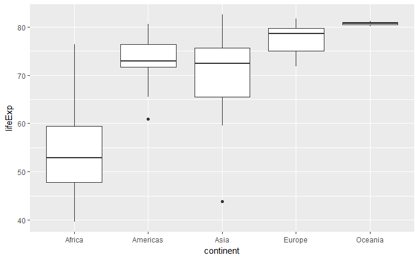

```r
# Generate box plots of lifeExp for each continent
gap2007 %>%
  ggplot(aes(x = continent, y = lifeExp)) +
  geom_boxplot()
```

Measures of variability

Calculate spread measures

```r
# Compute groupwise measures of spread
gap2007 %>%
  group_by(continent) %>%
  summarize(sd(lifeExp),
            IQR(lifeExp),
            n())
```

| continent | sd(lifeExp) | IQR(lifeExp) | n() |
| --- | --- | --- | --- |
| Africa | 9.6307807 | 11.61025 | 52 |
| Americas | 4.4409476 | 4.63200 | 25 |
| Asia | 7.9637245 | 10.15200 | 33 |
| Europe | 2.9798127 | 4.78250 | 30 |
| Oceania | 0.7290271 | 0.51550 | 2 |

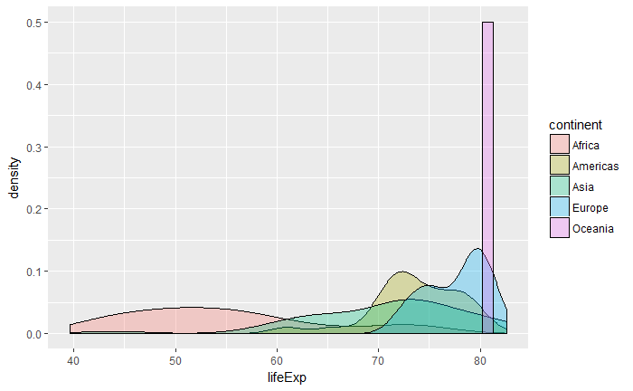

```r
# Generate overlaid density plots
gap2007 %>%
  ggplot(aes(x = lifeExp, fill = continent)) +
  geom_density(alpha = 0.3)
```

```r
# Compute stats for lifeExp in Americas
gap2007 %>%
  filter(continent == "Americas") %>%
  summarize(mean(lifeExp),
            sd(lifeExp))

# Compute stats for population
gap2007 %>%
  summarize(median(pop),
            IQR(pop))
```

[output not shown]

Shape and transformations

Center and spread; third is modality and skew

to treat the high skew: log transform

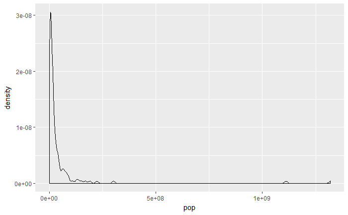

```r
# Create density plot of old variable
gap2007 %>%
  ggplot(aes(x = pop)) +
  geom_density()
```

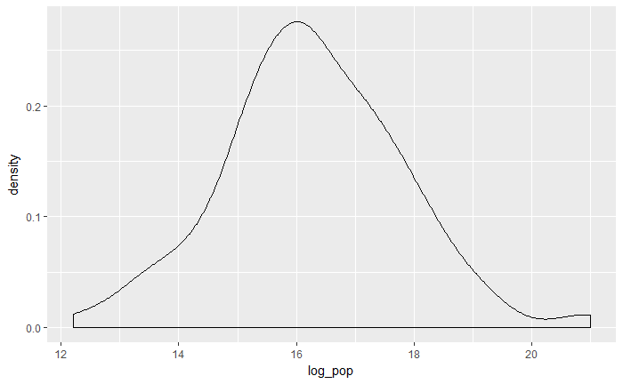

```r
# Transform the skewed pop variable
gap2007 <- gap2007 %>%
  mutate(log_pop = log(pop))
# Create density plot of new variable
gap2007 %>%
  ggplot(aes(x = log_pop)) +
  geom_density()
```

Outliers

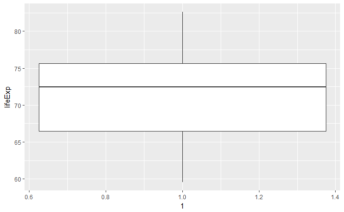

```r
# Filter for Asia, add column indicating outliers
gap_asia <- gap2007 %>%
  filter(continent == "Asia") %>%
  mutate(is_outlier = lifeExp < 50)
# Remove outliers, create box plot of lifeExp
gap_asia %>%
  filter(!is_outlier) %>%
  ggplot(aes(x = 1, y = lifeExp)) +
  geom_boxplot()
```

## 4. Case study

```r
# Load packages
library(ggplot2)
library(dplyr)
library(openintro)
# Compute summary statistics
email %>%
  group_by(spam) %>%
  summarize(median(num_char),
    IQR(num_char))
```

| spam | median(num_char) | IQR(num_char) |
| --- | --- | --- |
| 0 | 6.831 | 13.58225 |
| 1 | 1.046 | 2.81800 |

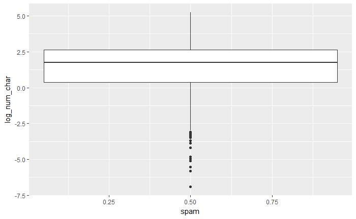

```r
# Create plot
email %>%
  mutate(log_num_char = log(num_char)) %>%
  ggplot(aes(x = spam, y = log_num_char)) +
  geom_boxplot()
```

Spam and !!!

[figure not shown]

Zero inflation strategies

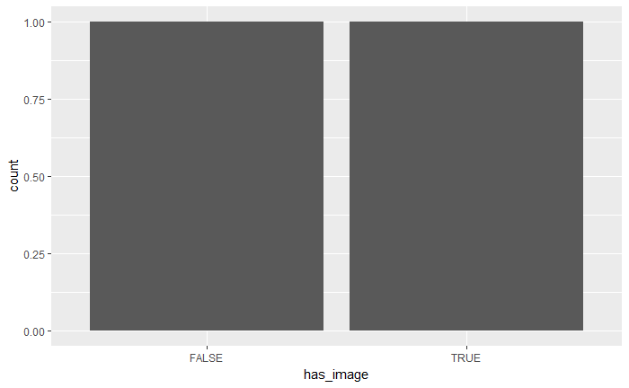

```r
# Create plot of proportion of spam by image
email %>%
  mutate(has_image = image > 0) %>%
  ggplot(aes(x = has_image, fill = spam)) +
  geom_bar(position = "fill")
```

```r
# Question 1
email %>%
  filter(dollar > 0 ) %>%
  group_by(spam) %>%
  summarize(median(dollar))
```

| spam | median(dollar) |
| --- | --- |
| 0 | 4 |
| 1 | 2 |

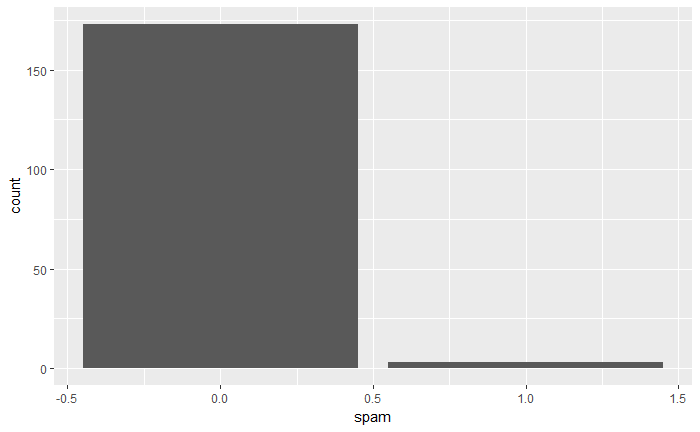

```r
# Question 2
email %>%
  filter(dollar > 10 ) %>%
  ggplot(aes(x = spam)) +
  geom_bar()
```

What’s in a number?

```r
# Reorder levels
email$number <- factor(email$number, levels = c("none", "small", "big"))

# Construct plot of number
ggplot(email, aes(x = number)) +
  geom_bar() +
  facet_wrap(~spam)
```

[output not shown]